# MonarchR Basics

Shawn T O’Neil

Vignette updated: *Jul-23-2024

# Background: Biomedical Knowledge Graphs

Knowledge graphs (KGs) represent entities (such as genes, diseases, or phenotypes) and the relationships between them; for example that the `CFTR` gene `causes` the disease `Cystic fibrosis`. In the [Monarch Initiative](https://monarchiniative.org) KG, this information is stored in a *directed, labeled property graph*, with properties attached to the entities (nodes) and relationships (edges). The [KGX format](https://github.com/biolink/kgx/blob/master/specification/kgx-format.md) used by Monarch provides a simple specification for KGs:

- Nodes must have an `id` property
- Nodes must have a `category` property, as a multi-valued set of category labels
- Edges must have `subject`, `predicate`, and `object` properties, representing the source, relationship, and destination of the edge.
- Nodes and edges may have additional properties, and these may be multi-valued.

In the following figure, these required properties are shown in bold:

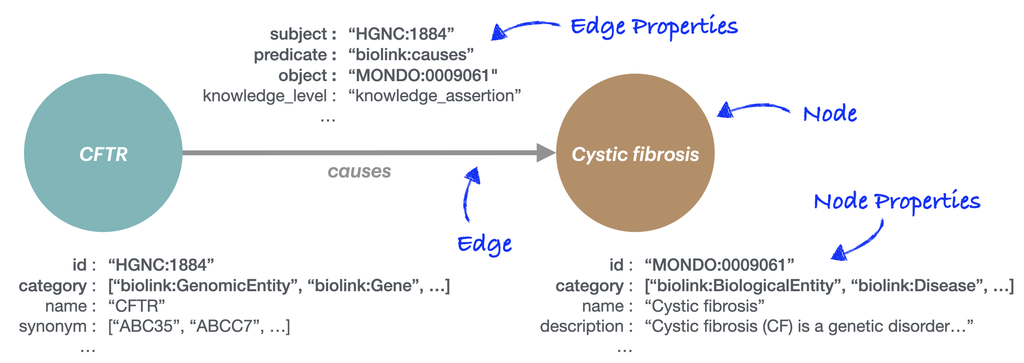

The `monarchr` package provides access to the cloud-hosted Monarch Initiative KG, and [others in KGX format](https://kghub.org) via graph-database and file-based “engines”, with a simple but flexible set of query functions. The example below finds all of the sub-types of [Neimann-Pick Disease](https://monarchinitiative.org/MONDO:0001982), and all of the genes associated with those. (You an use the [Monarch Initiative](https://monarchiniative.org) website to identify IDs for genes, diseases, phenotypes and more, or `search_nodes()` described below.)

```r
# MONDO:0001982 Niemann-Pick Disease (13 subtypes)

g <- monarch_engine() |>
  fetch_nodes(query_ids = c("MONDO:0001982")) |>
    expand(predicates = "biolink:subclass_of", direction = "in", transitive = TRUE) |>
    expand(categories = "biolink:Gene")
```

```
## Fetching; counting matching nodes...  total: 1.
## Fetching; fetched 1 of 1
## Expanding; counting matching edges...  total: 13.
## Expanding; fetched 13 of 13 edges.
## Expanding; counting matching edges...  total: 16.
## Expanding; fetched 16 of 16 edges.
```

```r
plot(g)
```

```
## Using "sugiyama" as default layout
```

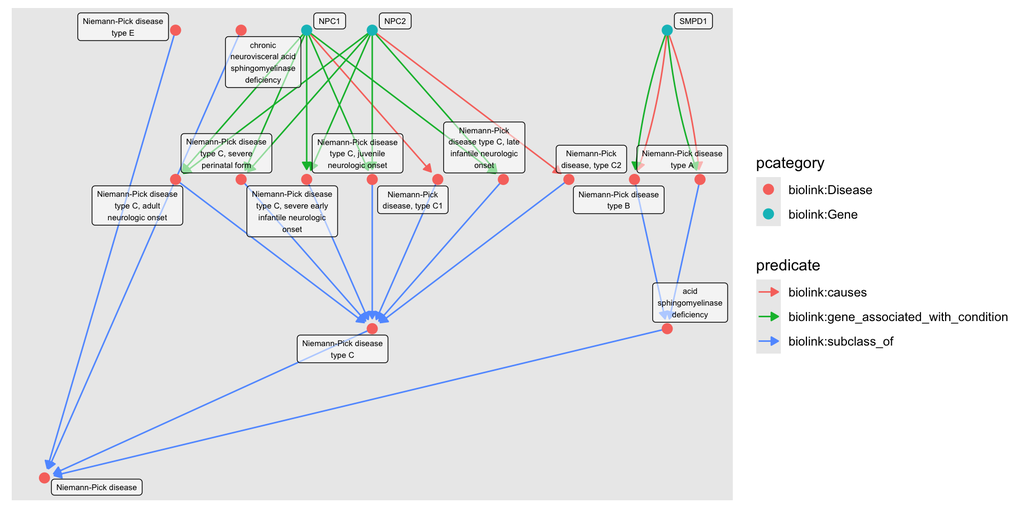

```
Graph with 17 nodes and 29 edges. Expand below to see details:
```

```r
g
```

**Node Data**

Showing 17 of 17 nodes:

| id | pcategory | name | symbol | in_taxon_label | description | synonym (list) | category (list) | iri | xref (list) | namespace | provided_by (list) | full_name | in_taxon (list) |
| --- | --- | --- | --- | --- | --- | --- | --- | --- | --- | --- | --- | --- | --- |
| “MONDO:0001982” | “biolink:Disease” | “Niemann-Pick disease” | NA | NA | “A group of inherited, severe metabolic disorders in which sphingomyelin accumulates in lysosomes in cells. The lysosomes normally transport material through and out of the cell.” | c(“Niemann-Pick disease with cholesterol esterification block”, “Niemann-Pick disease, subacute juvenile form”, “lipoid histiocytosis”, “lipoid histiocytosis (classical phosphatide)”, “sphingomyelin l… | c(“biolink:BiologicalEntity”, “biolink:Disease”, “biolink:DiseaseOrPhenotypicFeature”, “biolink:Entity”, “biolink:NamedThing”, “biolink:ThingWithTaxon”) | “http://purl.obolibrary.org/obo/MONDO_0001982” | c(“DOID:14504”, “EFO:1001380”, “GARD:13334”, “MESH:D009542”, “NANDO:2200561”, “NCIT:C61269”, “SCTID:58459009”, “UMLS:C0028064”) | “MONDO” | “phenio_nodes” | NA | NULL |
| “MONDO:0011873” | “biolink:Disease” | “Niemann-Pick disease, type C2” | NA | NA | “Niemann-Pick disease type C2 is a rare metabolic condition that affects many different parts of the body. Although signs and symptoms can develop at any age (infancy through adulthood), most affected… | c(“NPC2”, “Niemann-PICK disease, type C2”, “Niemann-Pick disease type C2”, “Niemann-Pick disease, type C2”, “type C2 Niemann-Pick disease”) | c(“biolink:BiologicalEntity”, “biolink:Disease”, “biolink:DiseaseOrPhenotypicFeature”, “biolink:Entity”, “biolink:NamedThing”, “biolink:ThingWithTaxon”) | “http://purl.obolibrary.org/obo/MONDO_0011873” | c(“DOID:0070114”, “GARD:3992”, “MESH:C536119”, “NCIT:C126865”, “OMIM:607625”, “UMLS:C1843366”) | “MONDO” | “phenio_nodes” | NA | NA |
| “MONDO:0018982” | “biolink:Disease” | “Niemann-Pick disease type C” | NA | NA | “NPC is a complex lipid storage disease mainly characterized by the accumulation of unesterified cholesterol in the late endosomal/lysosomal compartment.” | c(“NPC”, “Niemann Pick Disease Type C”) | c(“biolink:BiologicalEntity”, “biolink:Disease”, “biolink:DiseaseOrPhenotypicFeature”, “biolink:Entity”, “biolink:NamedThing”, “biolink:ThingWithTaxon”) | “http://purl.obolibrary.org/obo/MONDO_0018982” | c(“GARD:7207”, “MESH:D052556”, “NANDO:1200063”, “NORD:1509”, “Orphanet:646”, “SCTID:66751000”) | “MONDO” | “phenio_nodes” | NA | NULL |
| “MONDO:0011871” | “biolink:Disease” | “Niemann-Pick disease type B” | NA | NA | “Niemann-Pick disease type B is a mild subtype of Niemann-Pick disease, an autosomal recessive lysosomal disease, and is characterized clinically by onset in childhood with hepatosplenomegaly, growth … | c(“Niemann Pick disease type B”, “Niemann-PICK disease, type B”, “Niemann-Pick disease, Intermediate, with visceral involvement and rapid progression”, “Niemann-Pick disease, type E”, “Niemann-Pick di… | c(“biolink:BiologicalEntity”, “biolink:Disease”, “biolink:DiseaseOrPhenotypicFeature”, “biolink:Entity”, “biolink:NamedThing”, “biolink:ThingWithTaxon”) | “http://purl.obolibrary.org/obo/MONDO_0011871” | c(“DOID:0070112”, “GARD:10729”, “ICD10CM:E75.241”, “MESH:D052537”, “NANDO:1200062”, “NANDO:2201207”, “NCIT:C126866”, “OMIM:607616”, “Orphanet:77293”, “SCTID:39390005”, “UMLS:C0268243”) | “MONDO” | “phenio_nodes” | NA | NA |
| “MONDO:0100464” | “biolink:Disease” | “acid sphingomyelinase deficiency” | NA | NA | “An autosomal recessive lysosomal disease caused by biallelic loss of function variants in the SMPD1 gene. Clinical symptoms in affected individuals occur along a continuum. At the severe end of the s… | NA | c(“biolink:BiologicalEntity”, “biolink:Disease”, “biolink:DiseaseOrPhenotypicFeature”, “biolink:Entity”, “biolink:NamedThing”, “biolink:ThingWithTaxon”) | “http://purl.obolibrary.org/obo/MONDO_0100464” | NA | “MONDO” | “phenio_nodes” | NA | NULL |
| “MONDO:0009757” | “biolink:Disease” | “Niemann-Pick disease, type C1” | NA | NA | “Type C Niemann-Pick disease associated with a mutation in the gene NPC1, encoding Niemann-Pick C1 protein.” | c(“NPC1”, “Niemann-PICK disease, type C1”, “Niemann-Pick disease type C1”, “Niemann-Pick disease with cholesterol esterification block”, “Niemann-Pick disease without sphingomyelinase deficiency”, “Ni… | c(“biolink:BiologicalEntity”, “biolink:Disease”, “biolink:DiseaseOrPhenotypicFeature”, “biolink:Entity”, “biolink:NamedThing”, “biolink:ThingWithTaxon”) | “http://purl.obolibrary.org/obo/MONDO_0009757” | c(“DOID:0070113”, “NCIT:C126864”, “OMIM:257220”, “SCTID:18927009”, “UMLS:C3179455”) | “MONDO” | “phenio_nodes” | NA | NA |
| “MONDO:0009756” | “biolink:Disease” | “Niemann-Pick disease type A” | NA | NA | “Niemann-Pick disease type A is a very severe subtype of Niemann-Pick disease, an autosomal recessive lysosomal disease, and is characterized clinically by onset in infancy or early childhood with fai… | c(“Niemann-PICK disease, type A”, “Niemann-Pick disease, Intermediate, protracted neurovisceral”, “sphingomyelin lipidosis”, “sphingomyelinase deficiency”) | c(“biolink:BiologicalEntity”, “biolink:Disease”, “biolink:DiseaseOrPhenotypicFeature”, “biolink:Entity”, “biolink:NamedThing”, “biolink:ThingWithTaxon”) | “http://purl.obolibrary.org/obo/MONDO_0009756” | c(“DOID:0070111”, “GARD:7206”, “MESH:D052536”, “NANDO:1200061”, “NANDO:2201206”, “NCIT:C126561”, “OMIM:257200”, “Orphanet:77292”, “SCTID:52165006”, “UMLS:C0268242”) | “MONDO” | “phenio_nodes” | NA | NA |
| “MONDO:0016306” | “biolink:Disease” | “Niemann-Pick disease type C, severe perinatal form” | NA | NA | NA | NA | c(“biolink:BiologicalEntity”, “biolink:Disease”, “biolink:DiseaseOrPhenotypicFeature”, “biolink:Entity”, “biolink:NamedThing”, “biolink:ThingWithTaxon”) | “http://purl.obolibrary.org/obo/MONDO_0016306” | c(“GARD:20504”, “Orphanet:216972”) | “MONDO” | “phenio_nodes” | NA | NA |
| “MONDO:0016307” | “biolink:Disease” | “Niemann-Pick disease type C, severe early infantile neurologic onset” | NA | NA | NA | NA | c(“biolink:BiologicalEntity”, “biolink:Disease”, “biolink:DiseaseOrPhenotypicFeature”, “biolink:Entity”, “biolink:NamedThing”, “biolink:ThingWithTaxon”) | “http://purl.obolibrary.org/obo/MONDO_0016307” | c(“GARD:20505”, “Orphanet:216975”) | “MONDO” | “phenio_nodes” | NA | NA |
| “MONDO:0016308” | “biolink:Disease” | “Niemann-Pick disease type C, late infantile neurologic onset” | NA | NA | NA | NA | c(“biolink:BiologicalEntity”, “biolink:Disease”, “biolink:DiseaseOrPhenotypicFeature”, “biolink:Entity”, “biolink:NamedThing”, “biolink:ThingWithTaxon”) | “http://purl.obolibrary.org/obo/MONDO_0016308” | c(“GARD:20506”, “Orphanet:216978”) | “MONDO” | “phenio_nodes” | NA | NA |
| “MONDO:0016310” | “biolink:Disease” | “Niemann-Pick disease type C, adult neurologic onset” | NA | NA | NA | NA | c(“biolink:BiologicalEntity”, “biolink:Disease”, “biolink:DiseaseOrPhenotypicFeature”, “biolink:Entity”, “biolink:NamedThing”, “biolink:ThingWithTaxon”) | “http://purl.obolibrary.org/obo/MONDO_0016310” | c(“GARD:20508”, “NANDO:1200065”, “NANDO:2201209”, “Orphanet:216986”) | “MONDO” | “phenio_nodes” | NA | NA |
| “MONDO:0016309” | “biolink:Disease” | “Niemann-Pick disease type C, juvenile neurologic onset” | NA | NA | NA | “Niemann-Pick disease type C, classic form” | c(“biolink:BiologicalEntity”, “biolink:Disease”, “biolink:DiseaseOrPhenotypicFeature”, “biolink:Entity”, “biolink:NamedThing”, “biolink:ThingWithTaxon”) | “http://purl.obolibrary.org/obo/MONDO_0016309” | c(“GARD:20507”, “Orphanet:216981”) | “MONDO” | “phenio_nodes” | NA | NA |
| “MONDO:0020384” | “biolink:Disease” | “Niemann-Pick disease type E” | NA | NA | “Niemann-Pick disease, type E is a poorly defined adult-onset and non-neuronopathic form of Niemann-Pick disease.” | NA | c(“biolink:BiologicalEntity”, “biolink:Disease”, “biolink:DiseaseOrPhenotypicFeature”, “biolink:Entity”, “biolink:NamedThing”, “biolink:ThingWithTaxon”) | “http://purl.obolibrary.org/obo/MONDO_0020384” | c(“Orphanet:99022”, “SCTID:73399005”) | “MONDO” | “phenio_nodes” | NA | NULL |
| “MONDO:0850058” | “biolink:Disease” | “chronic neurovisceral acid sphingomyelinase deficiency” | NA | NA | NA | NA | c(“biolink:BiologicalEntity”, “biolink:Disease”, “biolink:DiseaseOrPhenotypicFeature”, “biolink:Entity”, “biolink:NamedThing”, “biolink:ThingWithTaxon”) | “http://purl.obolibrary.org/obo/MONDO_0850058” | c(“GARD:22456”, “Orphanet:618891”) | “MONDO” | “phenio_nodes” | NA | NULL |
| “HGNC:7897” | “biolink:Gene” | “NPC1” | “NPC1” | “Homo sapiens” | NA | c(“Niemann-Pick disease, type C1”, “SLC65A1”) | c(“biolink:BiologicalEntity”, “biolink:ChemicalEntityOrGeneOrGeneProduct”, “biolink:Entity”, “biolink:Gene”, “biolink:GeneOrGeneProduct”, “biolink:GenomicEntity”, “biolink:MacromolecularMachineMixin”,… | NA | c(“ENSEMBL:ENSG00000141458”, “OMIM:607623”) | “HGNC” | “hgnc_gene_nodes” | “NPC intracellular cholesterol transporter 1” | “NCBITaxon:9606” |
| “HGNC:14537” | “biolink:Gene” | “NPC2” | “NPC2” | “Homo sapiens” | NA | c(“EDDM1”, “HE1”, “NP-C2”, “Niemann-Pick disease, type C2”, “epididymal protein 1”) | c(“biolink:BiologicalEntity”, “biolink:ChemicalEntityOrGeneOrGeneProduct”, “biolink:Entity”, “biolink:Gene”, “biolink:GeneOrGeneProduct”, “biolink:GenomicEntity”, “biolink:MacromolecularMachineMixin”,… | NA | c(“ENSEMBL:ENSG00000119655”, “OMIM:601015”) | “HGNC” | “hgnc_gene_nodes” | “NPC intracellular cholesterol transporter 2” | “NCBITaxon:9606” |
| “HGNC:11120” | “biolink:Gene” | “SMPD1” | “SMPD1” | “Homo sapiens” | NA | c(“ASM”, “Niemann-Pick type A/B”, “acid sphingomyelinase”, “sphingomyelin phosphodiesterase 1, acid lysosomal”) | c(“biolink:BiologicalEntity”, “biolink:ChemicalEntityOrGeneOrGeneProduct”, “biolink:Entity”, “biolink:Gene”, “biolink:GeneOrGeneProduct”, “biolink:GenomicEntity”, “biolink:MacromolecularMachineMixin”,… | NA | c(“ENSEMBL:ENSG00000166311”, “OMIM:607608”) | “HGNC” | “hgnc_gene_nodes” | “sphingomyelin phosphodiesterase 1” | “NCBITaxon:9606” |

**Edge Data**

Showing 29 of 29 edges:

| from | to | subject | predicate | object | agent_type | knowledge_level | knowledge_source | aggregator_knowledge_source (list) | primary_knowledge_source | provided_by (list) | id | category (list) | original_subject | original_object |
| --- | --- | --- | --- | --- | --- | --- | --- | --- | --- | --- | --- | --- | --- | --- |
| 2 | 3 | “MONDO:0011873” | “biolink:subclass_of” | “MONDO:0018982” | “not_provided” | “not_provided” | “monarch-kg_edges.jsonl” | c(“infores:monarchinitiative”, “infores:phenio”) | “infores:mondo” | “phenio_edges” | “urn:uuid:869fd120-310a-4482-8e77-3016a318325b” | c(“biolink:Association”, “biolink:Entity”) | NA | NA |
| 4 | 5 | “MONDO:0011871” | “biolink:subclass_of” | “MONDO:0100464” | “not_provided” | “not_provided” | “monarch-kg_edges.jsonl” | c(“infores:monarchinitiative”, “infores:phenio”) | “infores:mondo” | “phenio_edges” | “urn:uuid:5d8b3ff4-8ec8-44bc-8e76-46fff5ad11cd” | c(“biolink:Association”, “biolink:Entity”) | NA | NA |
| 6 | 3 | “MONDO:0009757” | “biolink:subclass_of” | “MONDO:0018982” | “not_provided” | “not_provided” | “monarch-kg_edges.jsonl” | c(“infores:monarchinitiative”, “infores:phenio”) | “infores:mondo” | “phenio_edges” | “urn:uuid:fbebb7de-1cb9-4f90-932a-46819db221e8” | c(“biolink:Association”, “biolink:Entity”) | NA | NA |
| 7 | 5 | “MONDO:0009756” | “biolink:subclass_of” | “MONDO:0100464” | “not_provided” | “not_provided” | “monarch-kg_edges.jsonl” | c(“infores:monarchinitiative”, “infores:phenio”) | “infores:mondo” | “phenio_edges” | “urn:uuid:3ca10a53-3a7d-42cb-b9b2-2278ef8504ba” | c(“biolink:Association”, “biolink:Entity”) | NA | NA |
| 8 | 3 | “MONDO:0016306” | “biolink:subclass_of” | “MONDO:0018982” | “not_provided” | “not_provided” | “monarch-kg_edges.jsonl” | c(“infores:monarchinitiative”, “infores:phenio”) | “infores:mondo” | “phenio_edges” | “urn:uuid:4df66b1f-981b-4d05-a0eb-9986122673fc” | c(“biolink:Association”, “biolink:Entity”) | NA | NA |
| 9 | 3 | “MONDO:0016307” | “biolink:subclass_of” | “MONDO:0018982” | “not_provided” | “not_provided” | “monarch-kg_edges.jsonl” | c(“infores:monarchinitiative”, “infores:phenio”) | “infores:mondo” | “phenio_edges” | “urn:uuid:448c936b-6c74-4340-8d52-593f1835da95” | c(“biolink:Association”, “biolink:Entity”) | NA | NA |
| 10 | 3 | “MONDO:0016308” | “biolink:subclass_of” | “MONDO:0018982” | “not_provided” | “not_provided” | “monarch-kg_edges.jsonl” | c(“infores:monarchinitiative”, “infores:phenio”) | “infores:mondo” | “phenio_edges” | “urn:uuid:12b0ebc5-a33b-4b05-943f-528d753c2ccd” | c(“biolink:Association”, “biolink:Entity”) | NA | NA |
| 11 | 3 | “MONDO:0016310” | “biolink:subclass_of” | “MONDO:0018982” | “not_provided” | “not_provided” | “monarch-kg_edges.jsonl” | c(“infores:monarchinitiative”, “infores:phenio”) | “infores:mondo” | “phenio_edges” | “urn:uuid:966840e8-2184-48fa-9aaf-56b47c501352” | c(“biolink:Association”, “biolink:Entity”) | NA | NA |
| 12 | 3 | “MONDO:0016309” | “biolink:subclass_of” | “MONDO:0018982” | “not_provided” | “not_provided” | “monarch-kg_edges.jsonl” | c(“infores:monarchinitiative”, “infores:phenio”) | “infores:mondo” | “phenio_edges” | “urn:uuid:c88be317-99f7-4031-9aed-647ce2bbbc88” | c(“biolink:Association”, “biolink:Entity”) | NA | NA |
| 3 | 1 | “MONDO:0018982” | “biolink:subclass_of” | “MONDO:0001982” | “not_provided” | “not_provided” | “monarch-kg_edges.jsonl” | c(“infores:monarchinitiative”, “infores:phenio”) | “infores:mondo” | “phenio_edges” | “urn:uuid:3450e760-7666-43ec-819c-19d114fa9a88” | c(“biolink:Association”, “biolink:Entity”) | NA | NA |
| 13 | 1 | “MONDO:0020384” | “biolink:subclass_of” | “MONDO:0001982” | “not_provided” | “not_provided” | “monarch-kg_edges.jsonl” | c(“infores:monarchinitiative”, “infores:phenio”) | “infores:mondo” | “phenio_edges” | “urn:uuid:7ca6492d-0697-4a4f-8383-9c53e58add1e” | c(“biolink:Association”, “biolink:Entity”) | NA | NA |
| 5 | 1 | “MONDO:0100464” | “biolink:subclass_of” | “MONDO:0001982” | “not_provided” | “not_provided” | “monarch-kg_edges.jsonl” | c(“infores:monarchinitiative”, “infores:phenio”) | “infores:mondo” | “phenio_edges” | “urn:uuid:a62ee5a6-011c-44b2-b48e-2f0ab595dadb” | c(“biolink:Association”, “biolink:Entity”) | NA | NA |
| 14 | 1 | “MONDO:0850058” | “biolink:subclass_of” | “MONDO:0001982” | “not_provided” | “not_provided” | “monarch-kg_edges.jsonl” | c(“infores:monarchinitiative”, “infores:phenio”) | “infores:mondo” | “phenio_edges” | “urn:uuid:834c7761-1f42-454b-8726-9b85c3ab2bd5” | c(“biolink:Association”, “biolink:Entity”) | NA | NA |
| 15 | 6 | “HGNC:7897” | “biolink:causes” | “MONDO:0009757” | “manual_agent” | “knowledge_assertion” | “monarch-kg_edges.jsonl” | c(“infores:medgen”, “infores:monarchinitiative”) | “infores:omim” | “hpoa_gene_to_disease_edges” | “uuid:6337715f-400a-11ef-89e7-6fe0be41fbbf” | c(“biolink:Association”, “biolink:CausalGeneToDiseaseAssociation”, “biolink:Entity”, “biolink:EntityToDiseaseAssociationMixin”, “biolink:EntityToFeatureOrDiseaseQualifiersMixin”, “biolink:EntityToPhen… | “NCBIGene:4864” | “OMIM:257220” |
| 16 | 2 | “HGNC:14537” | “biolink:causes” | “MONDO:0011873” | “manual_agent” | “knowledge_assertion” | “monarch-kg_edges.jsonl” | c(“infores:medgen”, “infores:monarchinitiative”) | “infores:omim” | “hpoa_gene_to_disease_edges” | “uuid:631aaa18-400a-11ef-89e7-6fe0be41fbbf” | c(“biolink:Association”, “biolink:CausalGeneToDiseaseAssociation”, “biolink:Entity”, “biolink:EntityToDiseaseAssociationMixin”, “biolink:EntityToFeatureOrDiseaseQualifiersMixin”, “biolink:EntityToPhen… | “NCBIGene:10577” | “OMIM:607625” |
| 17 | 4 | “HGNC:11120” | “biolink:causes” | “MONDO:0011871” | “manual_agent” | “knowledge_assertion” | “monarch-kg_edges.jsonl” | c(“infores:medgen”, “infores:monarchinitiative”) | “infores:omim” | “hpoa_gene_to_disease_edges” | “uuid:631aaa33-400a-11ef-89e7-6fe0be41fbbf” | c(“biolink:Association”, “biolink:CausalGeneToDiseaseAssociation”, “biolink:Entity”, “biolink:EntityToDiseaseAssociationMixin”, “biolink:EntityToFeatureOrDiseaseQualifiersMixin”, “biolink:EntityToPhen… | “NCBIGene:6609” | “OMIM:607616” |
| 17 | 7 | “HGNC:11120” | “biolink:causes” | “MONDO:0009756” | “manual_agent” | “knowledge_assertion” | “monarch-kg_edges.jsonl” | c(“infores:medgen”, “infores:monarchinitiative”) | “infores:omim” | “hpoa_gene_to_disease_edges” | “uuid:633771f1-400a-11ef-89e7-6fe0be41fbbf” | c(“biolink:Association”, “biolink:CausalGeneToDiseaseAssociation”, “biolink:Entity”, “biolink:EntityToDiseaseAssociationMixin”, “biolink:EntityToFeatureOrDiseaseQualifiersMixin”, “biolink:EntityToPhen… | “NCBIGene:6609” | “OMIM:257200” |
| 15 | 8 | “HGNC:7897” | “biolink:gene_associated_with_condition” | “MONDO:0016306” | “manual_agent” | “knowledge_assertion” | “monarch-kg_edges.jsonl” | “infores:monarchinitiative” | “infores:orphanet” | “hpoa_gene_to_disease_edges” | “uuid:635d9131-400a-11ef-89e7-6fe0be41fbbf” | c(“biolink:Association”, “biolink:CorrelatedGeneToDiseaseAssociation”, “biolink:Entity”, “biolink:EntityToDiseaseAssociationMixin”, “biolink:EntityToFeatureOrDiseaseQualifiersMixin”, “biolink:EntityTo… | “NCBIGene:4864” | “Orphanet:216972” |
| 15 | 9 | “HGNC:7897” | “biolink:gene_associated_with_condition” | “MONDO:0016307” | “manual_agent” | “knowledge_assertion” | “monarch-kg_edges.jsonl” | “infores:monarchinitiative” | “infores:orphanet” | “hpoa_gene_to_disease_edges” | “uuid:635d9133-400a-11ef-89e7-6fe0be41fbbf” | c(“biolink:Association”, “biolink:CorrelatedGeneToDiseaseAssociation”, “biolink:Entity”, “biolink:EntityToDiseaseAssociationMixin”, “biolink:EntityToFeatureOrDiseaseQualifiersMixin”, “biolink:EntityTo… | “NCBIGene:4864” | “Orphanet:216975” |
| 15 | 10 | “HGNC:7897” | “biolink:gene_associated_with_condition” | “MONDO:0016308” | “manual_agent” | “knowledge_assertion” | “monarch-kg_edges.jsonl” | “infores:monarchinitiative” | “infores:orphanet” | “hpoa_gene_to_disease_edges” | “uuid:635d9137-400a-11ef-89e7-6fe0be41fbbf” | c(“biolink:Association”, “biolink:CorrelatedGeneToDiseaseAssociation”, “biolink:Entity”, “biolink:EntityToDiseaseAssociationMixin”, “biolink:EntityToFeatureOrDiseaseQualifiersMixin”, “biolink:EntityTo… | “NCBIGene:4864” | “Orphanet:216978” |
| 15 | 11 | “HGNC:7897” | “biolink:gene_associated_with_condition” | “MONDO:0016310” | “manual_agent” | “knowledge_assertion” | “monarch-kg_edges.jsonl” | “infores:monarchinitiative” | “infores:orphanet” | “hpoa_gene_to_disease_edges” | “uuid:635d9179-400a-11ef-89e7-6fe0be41fbbf” | c(“biolink:Association”, “biolink:CorrelatedGeneToDiseaseAssociation”, “biolink:Entity”, “biolink:EntityToDiseaseAssociationMixin”, “biolink:EntityToFeatureOrDiseaseQualifiersMixin”, “biolink:EntityTo… | “NCBIGene:4864” | “Orphanet:216986” |
| 15 | 12 | “HGNC:7897” | “biolink:gene_associated_with_condition” | “MONDO:0016309” | “manual_agent” | “knowledge_assertion” | “monarch-kg_edges.jsonl” | “infores:monarchinitiative” | “infores:orphanet” | “hpoa_gene_to_disease_edges” | “uuid:635d9185-400a-11ef-89e7-6fe0be41fbbf” | c(“biolink:Association”, “biolink:CorrelatedGeneToDiseaseAssociation”, “biolink:Entity”, “biolink:EntityToDiseaseAssociationMixin”, “biolink:EntityToFeatureOrDiseaseQualifiersMixin”, “biolink:EntityTo… | “NCBIGene:4864” | “Orphanet:216981” |
| 16 | 8 | “HGNC:14537” | “biolink:gene_associated_with_condition” | “MONDO:0016306” | “manual_agent” | “knowledge_assertion” | “monarch-kg_edges.jsonl” | “infores:monarchinitiative” | “infores:orphanet” | “hpoa_gene_to_disease_edges” | “uuid:635d9130-400a-11ef-89e7-6fe0be41fbbf” | c(“biolink:Association”, “biolink:CorrelatedGeneToDiseaseAssociation”, “biolink:Entity”, “biolink:EntityToDiseaseAssociationMixin”, “biolink:EntityToFeatureOrDiseaseQualifiersMixin”, “biolink:EntityTo… | “NCBIGene:10577” | “Orphanet:216972” |
| 16 | 9 | “HGNC:14537” | “biolink:gene_associated_with_condition” | “MONDO:0016307” | “manual_agent” | “knowledge_assertion” | “monarch-kg_edges.jsonl” | “infores:monarchinitiative” | “infores:orphanet” | “hpoa_gene_to_disease_edges” | “uuid:635d9132-400a-11ef-89e7-6fe0be41fbbf” | c(“biolink:Association”, “biolink:CorrelatedGeneToDiseaseAssociation”, “biolink:Entity”, “biolink:EntityToDiseaseAssociationMixin”, “biolink:EntityToFeatureOrDiseaseQualifiersMixin”, “biolink:EntityTo… | “NCBIGene:10577” | “Orphanet:216975” |
| 16 | 10 | “HGNC:14537” | “biolink:gene_associated_with_condition” | “MONDO:0016308” | “manual_agent” | “knowledge_assertion” | “monarch-kg_edges.jsonl” | “infores:monarchinitiative” | “infores:orphanet” | “hpoa_gene_to_disease_edges” | “uuid:635d9136-400a-11ef-89e7-6fe0be41fbbf” | c(“biolink:Association”, “biolink:CorrelatedGeneToDiseaseAssociation”, “biolink:Entity”, “biolink:EntityToDiseaseAssociationMixin”, “biolink:EntityToFeatureOrDiseaseQualifiersMixin”, “biolink:EntityTo… | “NCBIGene:10577” | “Orphanet:216978” |
| 16 | 11 | “HGNC:14537” | “biolink:gene_associated_with_condition” | “MONDO:0016310” | “manual_agent” | “knowledge_assertion” | “monarch-kg_edges.jsonl” | “infores:monarchinitiative” | “infores:orphanet” | “hpoa_gene_to_disease_edges” | “uuid:635d9178-400a-11ef-89e7-6fe0be41fbbf” | c(“biolink:Association”, “biolink:CorrelatedGeneToDiseaseAssociation”, “biolink:Entity”, “biolink:EntityToDiseaseAssociationMixin”, “biolink:EntityToFeatureOrDiseaseQualifiersMixin”, “biolink:EntityTo… | “NCBIGene:10577” | “Orphanet:216986” |
| 16 | 12 | “HGNC:14537” | “biolink:gene_associated_with_condition” | “MONDO:0016309” | “manual_agent” | “knowledge_assertion” | “monarch-kg_edges.jsonl” | “infores:monarchinitiative” | “infores:orphanet” | “hpoa_gene_to_disease_edges” | “uuid:635d9184-400a-11ef-89e7-6fe0be41fbbf” | c(“biolink:Association”, “biolink:CorrelatedGeneToDiseaseAssociation”, “biolink:Entity”, “biolink:EntityToDiseaseAssociationMixin”, “biolink:EntityToFeatureOrDiseaseQualifiersMixin”, “biolink:EntityTo… | “NCBIGene:10577” | “Orphanet:216981” |
| 17 | 4 | “HGNC:11120” | “biolink:gene_associated_with_condition” | “MONDO:0011871” | “manual_agent” | “knowledge_assertion” | “monarch-kg_edges.jsonl” | “infores:monarchinitiative” | “infores:orphanet” | “hpoa_gene_to_disease_edges” | “uuid:6379fea2-400a-11ef-89e7-6fe0be41fbbf” | c(“biolink:Association”, “biolink:CorrelatedGeneToDiseaseAssociation”, “biolink:Entity”, “biolink:EntityToDiseaseAssociationMixin”, “biolink:EntityToFeatureOrDiseaseQualifiersMixin”, “biolink:EntityTo… | “NCBIGene:6609” | “Orphanet:77293” |
| 17 | 7 | “HGNC:11120” | “biolink:gene_associated_with_condition” | “MONDO:0009756” | “manual_agent” | “knowledge_assertion” | “monarch-kg_edges.jsonl” | “infores:monarchinitiative” | “infores:orphanet” | “hpoa_gene_to_disease_edges” | “uuid:6379fea3-400a-11ef-89e7-6fe0be41fbbf” | c(“biolink:Association”, “biolink:CorrelatedGeneToDiseaseAssociation”, “biolink:Entity”, “biolink:EntityToDiseaseAssociationMixin”, “biolink:EntityToFeatureOrDiseaseQualifiersMixin”, “biolink:EntityTo… | “NCBIGene:6609” | “Orphanet:77292” |

Backed by `tidygraph` and `igraph`, `monarchr` is part of a larger ecosystem of graph analyses in R:

- Graph joins, filters, and other manipulation: [`tidygraph`](https://tidygraph.data-imaginist.com/)
- Visualization:
  - ggplot-based: [`ggraph`](https://ggraph.data-imaginist.com/),
  - Interactive: [`visNetwork`](https://datastorm-open.github.io/visNetwork/), [`threejs`](https://bwlewis.github.io/rthreejs/)
- Exploratory analyses: [`EGAnet`](https://r-ega.net/)
- Graph algorithms:
  - Various: [`igraph`](https://r.igraph.org/reference/index.html), [`migraph`](https://cran.r-project.org/web/packages/migraph/index.html), [`netrankr`](https://github.com/schochastics/netrankr/)
  - Matching: [`iGraphMatch`](https://cran.r-project.org/web/packages/iGraphMatch/vignettes/iGraphMatch.html)
  - Graph neural networks: [`spinner`](https://rpubs.com/giancarlo_vercellino/spinner)
  - Clustering: [`clustAnalytics`](https://cran.r-project.org/web/packages/clustAnalytics/index.html)
  - Community detection: [`leidenAlg`](https://github.com/kharchenkolab/leidenAlg)
  - Link prediction: [`linkprediction`](https://cran.r-project.org/web/packages/linkprediction/index.html)
- Other:
  - Particle/force-based simulation: [`particles`](https://github.com/thomasp85/particles)
  - … others in the reverse imports for [`igraph`](https://cran.r-project.org/web/packages/igraph/index.html)